# R plots by Pawel Mrozowski

# Overview

```
##      X1965     X1966          X1967          X1968          X1969
##  Min.   :0    Mode:logical   Mode:logical   Mode:logical   Mode:logical
##  1st Qu.:0    NA's:257       NA's:257       NA's:257       NA's:257
##  Median :0
##  Mean   :0
##  3rd Qu.:0
##  Max.   :0
##  NA's   :61
##      X1970     X1971          X1972          X1973          X1974
##  Min.   :0    Mode:logical   Mode:logical   Mode:logical   Mode:logical
##  1st Qu.:0    NA's:257       NA's:257       NA's:257       NA's:257
##  Median :0
##  Mean   :0
##  3rd Qu.:0
##  Max.   :0
##  NA's   :61
##      X1975        X1976        X1977        X1978        X1979
##  Min.   :0    Min.   :0    Min.   :0    Min.   :0    Min.   :0
##  1st Qu.:0    1st Qu.:0    1st Qu.:0    1st Qu.:0    1st Qu.:0
##  Median :0    Median :0    Median :0    Median :0    Median :0
##  Mean   :0    Mean   :0    Mean   :0    Mean   :0    Mean   :0
##  3rd Qu.:0    3rd Qu.:0    3rd Qu.:0    3rd Qu.:0    3rd Qu.:0
##  Max.   :0    Max.   :0    Max.   :0    Max.   :0    Max.   :0
##  NA's   :61   NA's   :61   NA's   :61   NA's   :61   NA's   :61
##      X1980             X1981             X1982             X1983
##  Min.   :    0.0   Min.   :    0.0   Min.   :    0.0   Min.   :    0.0
##  1st Qu.:    0.0   1st Qu.:    0.0   1st Qu.:    0.0   1st Qu.:    0.0
##  Median :    0.0   Median :    0.0   Median :    0.0   Median :    0.0
##  Mean   :  119.8   Mean   :  326.1   Mean   :  520.6   Mean   :  767.3
##  3rd Qu.:    0.0   3rd Qu.:    0.0   3rd Qu.:    0.0   3rd Qu.:    0.0
##  Max.   :23482.0   Max.   :28278.0   Max.   :33880.0   Max.   :42226.0
##  NA's   :61        NA's   :62        NA's   :62        NA's   :63
##      X1984           X1985            X1986            X1987
##  Min.   :    0   Min.   :     0   Min.   :     0   Min.   :      0
##  1st Qu.:    0   1st Qu.:     0   1st Qu.:     0   1st Qu.:      0
##  Median :    0   Median :     0   Median :     0   Median :      0
##  Mean   : 1663   Mean   :  3930   Mean   :  7514   Mean   :  13326
##  3rd Qu.:    0   3rd Qu.:     0   3rd Qu.:     0   3rd Qu.:      0
##  Max.   :91600   Max.   :340213   Max.   :681825   Max.   :1230855
##  NA's   :65      NA's   :66       NA's   :64       NA's   :66
```

[output cut: 49 more lines]

```
##  Min.   :        0   Min.   :        0   Min.   :     1000
##  1st Qu.:   380418   1st Qu.:   600000   1st Qu.:   668237
##  Median :  2501140   Median :  3394016   Median :  4081632
##  Mean   : 16558541   Mean   : 19928682   Mean   : 22870061
##  3rd Qu.:  9932983   3rd Qu.: 11684479   3rd Qu.: 13227396
##  Max.   :547306000   Max.   :641245000   Max.   :747214000
##  NA's   :55          NA's   :56          NA's   :55
##      X2010               X2011
##  Min.   :     1600   Min.   :     2130
##  1st Qu.:   956924   1st Qu.:  1324654
##  Median :  4909666   Median :  6426526
##  Mean   : 26403896   Mean   : 31216042
##  3rd Qu.: 14040479   3rd Qu.: 18129152
##  Max.   :859003000   Max.   :986253000
##  NA's   :57          NA's   :67
```

```
##                       X1965 X1966 X1967 X1968 X1969 X1970 X1971 X1972
## Afghanistan               0    NA    NA    NA    NA     0    NA    NA
## Akrotiri and Dhekelia    NA    NA    NA    NA    NA    NA    NA    NA
## Albania                   0    NA    NA    NA    NA     0    NA    NA
## Algeria                   0    NA    NA    NA    NA     0    NA    NA
## American Samoa            0    NA    NA    NA    NA     0    NA    NA
## Andorra                   0    NA    NA    NA    NA     0    NA    NA
##                       X1973 X1974 X1975 X1976 X1977 X1978 X1979 X1980
## Afghanistan              NA    NA     0     0     0     0     0     0
## Akrotiri and Dhekelia    NA    NA    NA    NA    NA    NA    NA    NA
## Albania                  NA    NA     0     0     0     0     0     0
## Algeria                  NA    NA     0     0     0     0     0     0
## American Samoa           NA    NA     0     0     0     0     0     0
## Andorra                  NA    NA     0     0     0     0     0     0
##                       X1981 X1982 X1983 X1984 X1985 X1986 X1987 X1988
## Afghanistan               0     0     0     0     0     0     0     0
## Akrotiri and Dhekelia    NA    NA    NA    NA    NA    NA    NA    NA
## Albania                   0     0     0     0     0     0     0     0
## Algeria                   0     0     0     0     0     0     0     0
## American Samoa            0     0     0     0     0     0    NA    NA
## Andorra                   0     0     0     0     0     0     0     0
##                       X1989 X1990 X1991 X1992 X1993 X1994 X1995 X1996
## Afghanistan               0     0     0     0     0     0     0     0
## Akrotiri and Dhekelia    NA    NA    NA    NA    NA    NA    NA    NA
## Albania                   0     0     0     0     0     0     0  2300
## Algeria                   0   470  4781  4781  4781  1348  4691 11700
## American Samoa           NA     0     0   700   900  1200  1250  1300
## Andorra                   0     0     0   770   780   784  2825  5488
##                       X1997 X1998 X1999 X2000  X2001  X2002   X2003
## Afghanistan               0     0     0     0      0  25000  200000
## Akrotiri and Dhekelia    NA    NA    NA    NA     NA     NA      NA
## Albania                3300  5600 11008 29791 392650 851000 1100000
## Algeria               17400 18000 72000 86000 100000 450244 1446927
## American Samoa         1400  1500  1800  1992   2156   2036    2100
## Andorra                8618 14117 20600 23543  29429  32790   51893
##                         X2004    X2005    X2006    X2007    X2008    X2009
## Afghanistan            600000  1200000  2520366  4668096  7898909 10500000
## Akrotiri and Dhekelia      NA       NA       NA       NA       NA       NA
## Albania               1259590  1530244  1909885  2322436  1859632  2463741
## Algeria               4882414 13661355 20997954 27562721 27031472 32729824
## American Samoa           2250       NA       NA       NA       NA       NA
## Andorra                 58366    64560    69004    63503    64202    64549
##                          X2010    X2011
## Afghanistan           13000000 17558265
## Akrotiri and Dhekelia       NA       NA
## Albania                2692372  3100000
## Algeria               32780165 35615926
## American Samoa              NA       NA
## Andorra                  65495    65044
```

Before we begin I want to plot the summary data in relation to years in out dataset. (y is logarithmic scale)

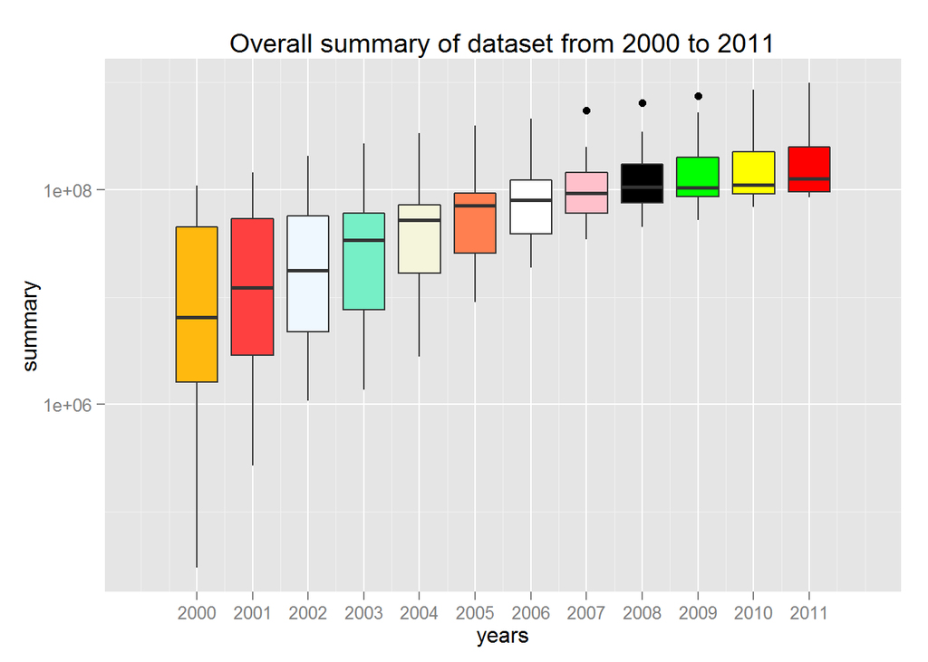

We can that the cell quantity in following years is increasing and that the spread between lower and upper limit is getting smaller. Also the average value is stabilizing.

# Univariate Analysis

Firstly I want to visualize few years taken arbitrary, if there is some kind of a trend all over the world in cell quantity. I take year 1980 (that is actually the start of Centertell in scandinavian countries) and 20 years after.

Firstly we try to take a look on quantity of phones in top 5 countries in year 1980.

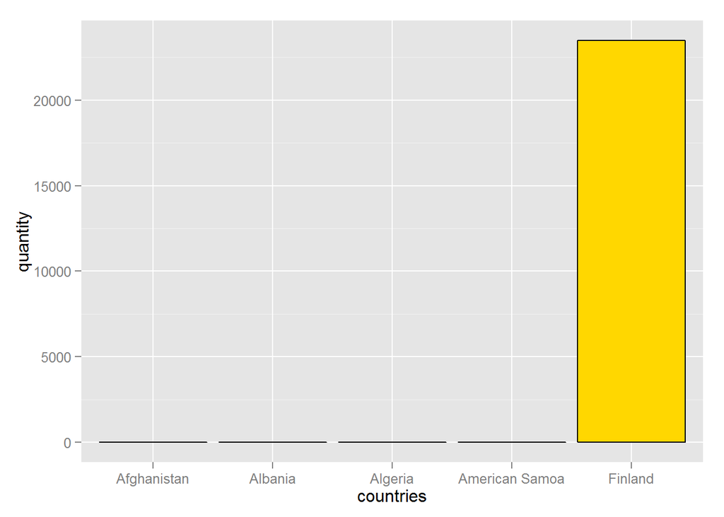

So we have confirmation that in fact the only country in the dataset that had cell phones was Finland.

then we choose proper column tht ocntains year 2010

```
##    X2010
## 19202834
```

Now we add this as layer to plot and

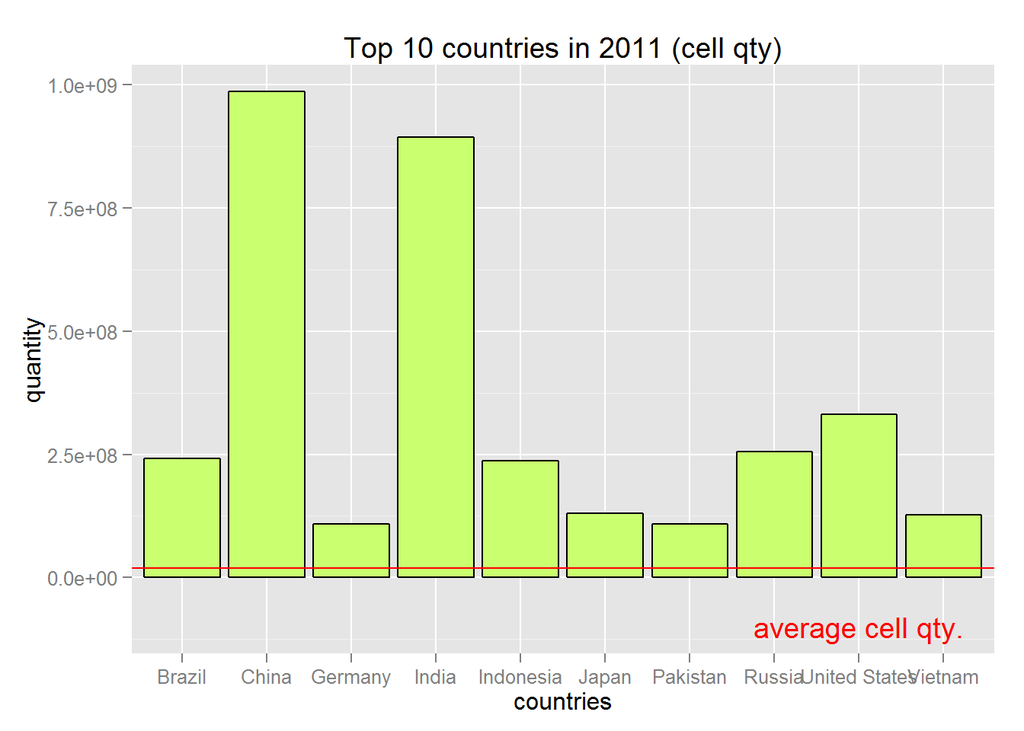

Now last thing we want to know is how many countries have quantity above average. We can see that most of countries in our db is below an average, but some of them (the biggest one like USA and China) significanly imcrease overall statistics.

# Bivariate Analysis

Here we begin bivariate analysis. The structure of dataset is simple. From one side we have Countries, from the other we have rows/columns with cell phone quantities since 1965 till 2011 as separated values. So actually to begin analysis we must create some new variables like average/total amount by binding some data.We are going to compare overall data set characteristics with my country Poland.

We want to answer a few questions: 1- how the total amount of phones changed over time 2- how the total amount of phones changed in Poland and compare it with global analysis 3- how is the relation between world trend to my country’s trend

Since the data is in separated columns we must build two variables: years and total

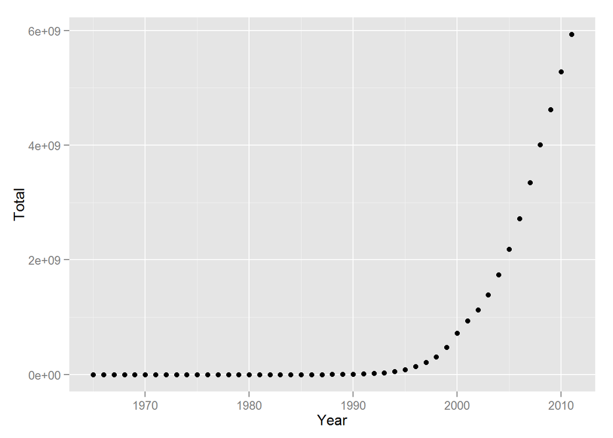

Now we can narrow this growth to one country, e.g. Poland and compare this with total value for all dataset.

Now let’s visualize cell quantity in Poland using linear scale.

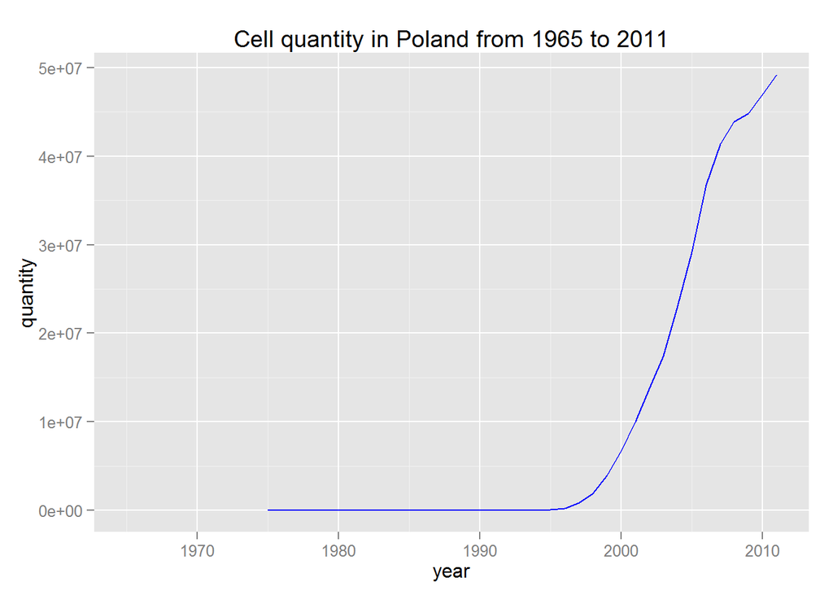

We can see that significant increase occured in 1995 till 2005.

To see it better the dynamics and since the values increase very fast we tried to change the scale on y-axis to be logarithmic.

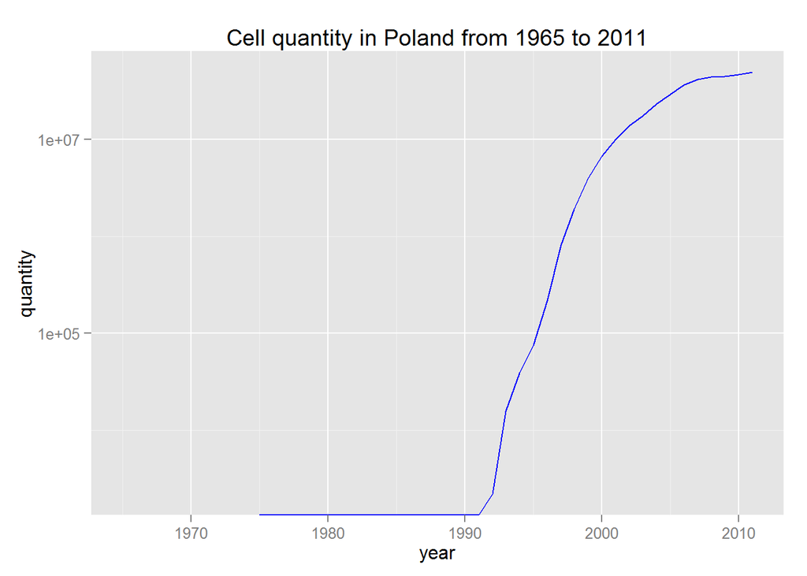

We can now compare both values and avarage in the world: plots on one graph to see how Poland is related to overall total number

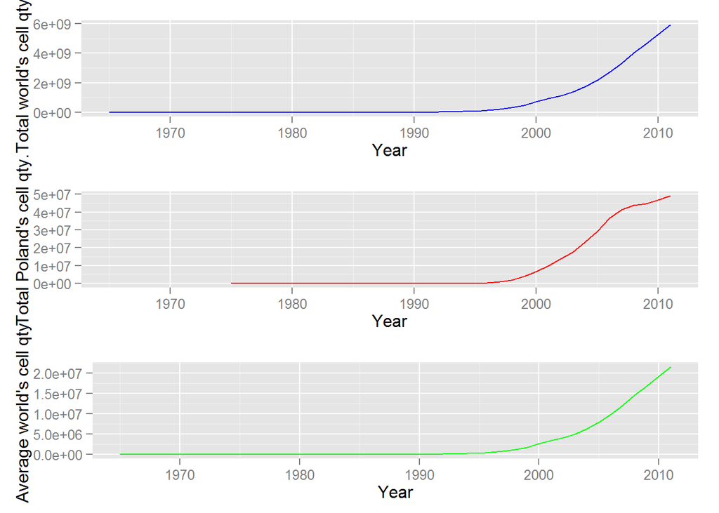

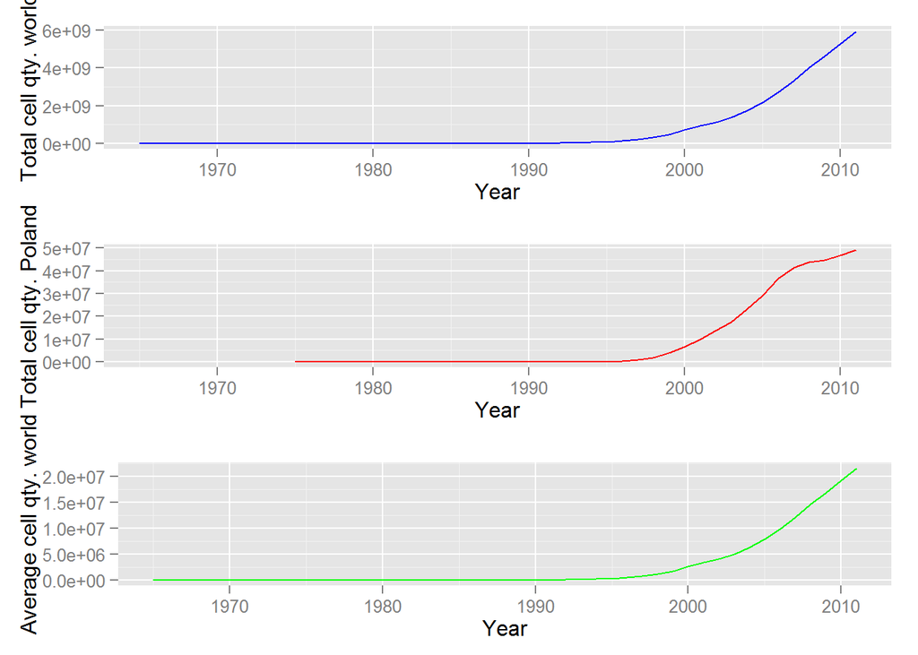

We can see that the shape of function is similar but is relatively x times less (obvious) but also started about 10 years after world’s trend, which is justified taking into account the political aspect of Poland. Year 1989 is actually the fists year of capitalism and end of communism, so country coud benefit from hith tech that was forbidden before.

Now I want to compare Poland’s ratio (relation of choosen year’s cell quantity to previous year) in increase in last 5 years vs our neighbour. This can help to understand in Polish market is actually growing fast .

Let’s calculate ratios (cell quantity of choosen year in relation to previous year):

Now we can plot the change of ratios in Poland (first we will add X axis to make our plots easier and cleaner).

```
##                             V179
## pf$X2006/pf$X2005      1.2598560
## ratio2001to2000        1.4828310
## ratio2002to2001        1.3891996
## ratio2003to2002        1.2520242
## ratio2004to2003        1.3272668
## ratio2005to2004        1.2628294
## ratio2006to2005        1.2598560
## ratio2007to2006        1.1263645
## ratio2008to2007        1.0613111
## ratio2009to2008        1.0200396
## ratio2010to2009        1.0478831
## ratio2011to2010        1.0478762
## ratio2011to2010tablets 0.5811255
## ratio2010to2009tablets 3.0019108
```

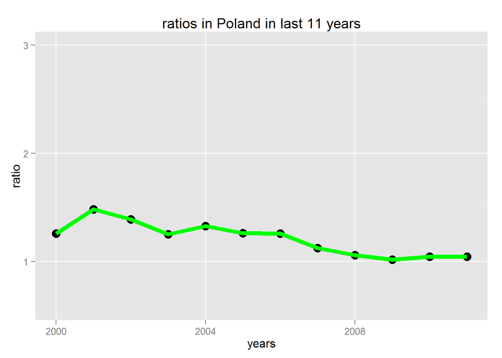

We can see that ratio (relation of current quantity to previous year’s quantity) of phones each year decreases almost to 1, so we see that the market is stabilizing and becomes full.

let’s do the same with Germany and try to find some correlation:

```
##                             V81
## pf$X2006/pf$X2005      1.450972
## ratio2001to2000        1.547322
## ratio2002to2001        1.671337
## ratio2003to2002        1.412226
## ratio2004to2003        1.181969
## ratio2005to2004        1.396913
## ratio2006to2005        1.450972
## ratio2007to2006        1.525754
## ratio2008to2007        1.059765
## ratio2009to2008        1.029732
## ratio2010to2009        1.402890
## ratio2011to2010        1.113219
## ratio2011to2010tablets 4.177911
## ratio2010to2009tablets 1.576335
```

[figure not shown]

But how is the relation between those two:

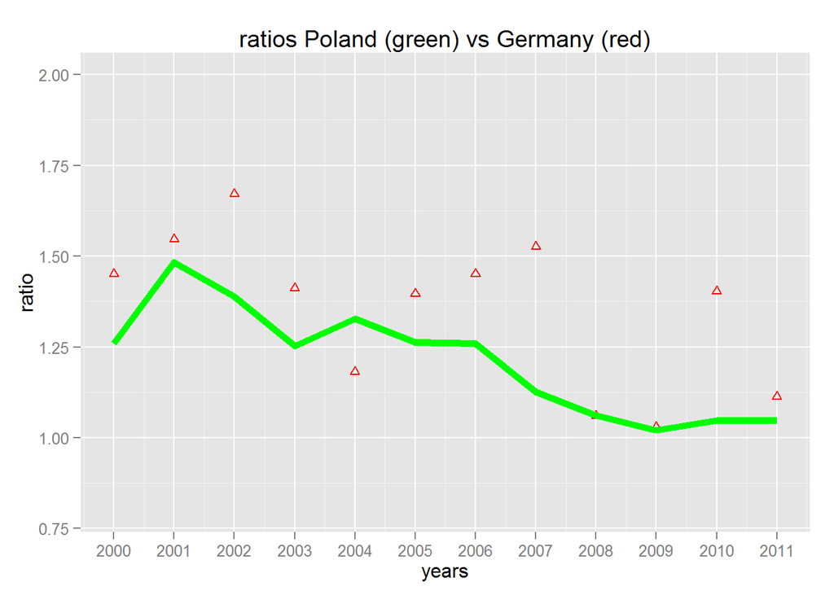

Finally we want to see the relation of ratios from 2000 to 2011 for all countries in the dataset. This gives an overview how previous ratio (year before) is related to the ratio in next year , if tendency is generally dropping or rising as a reaction to overall marked need.

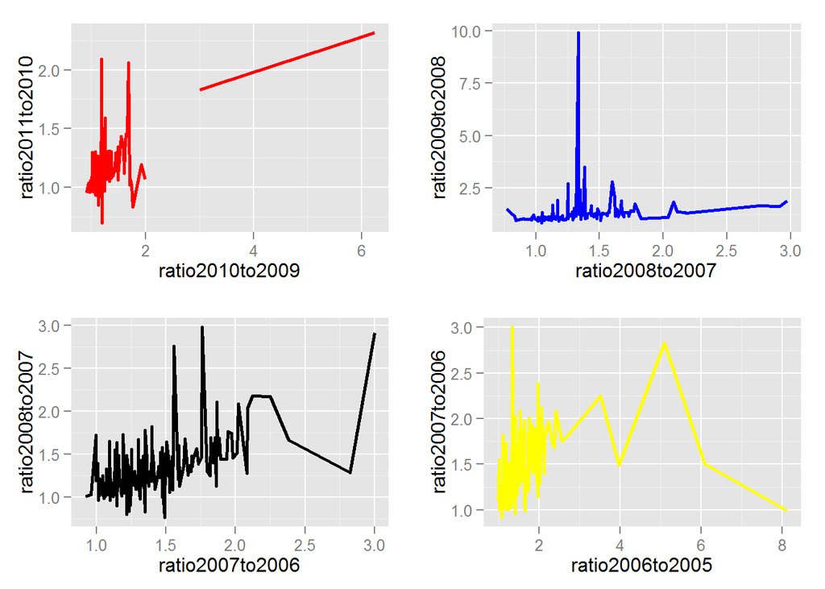

The shape of functions can be very different. All is related to global market trends, growths and market collapses. Taking a look at the plots, for example, on comparison of cell phone quantity ratios from 2008/2007 to 2009/2008 we can see a big spike. This is our exception (Kiribati) where ratio from about 1.4 has spiked to 9.9. Overall we observe steady growth. The same analysis relates to other trhee sub - plots.

From here we can try to find out the ratio trends related to new technologies available like incorporation of 3G networks or any other global market events (related to globalization). To be more precisely we would need to have better dataset.

# Multivariate

In this section we want to make similar analysis like in bivariate secion, but in relation to tables quantity sold in 2009/2010/2011.

Having some data (added manually with some randomness) about tablets in the last 3 years, we want to answer question like:

- what is the relationship between cell quantity ratios 2011/2010 and it’s relation to tablets ratio 2011/2010

Let’s assume (based on added data) that the general trend is increasing.

On the plot we can see cells quantity (dots) and tablets quantity (bars). The size of dots shows cell quantity, bars represent tablets quantity in 2011. the ratio of growth/drop of tablet quantity between 2011 and 2010.

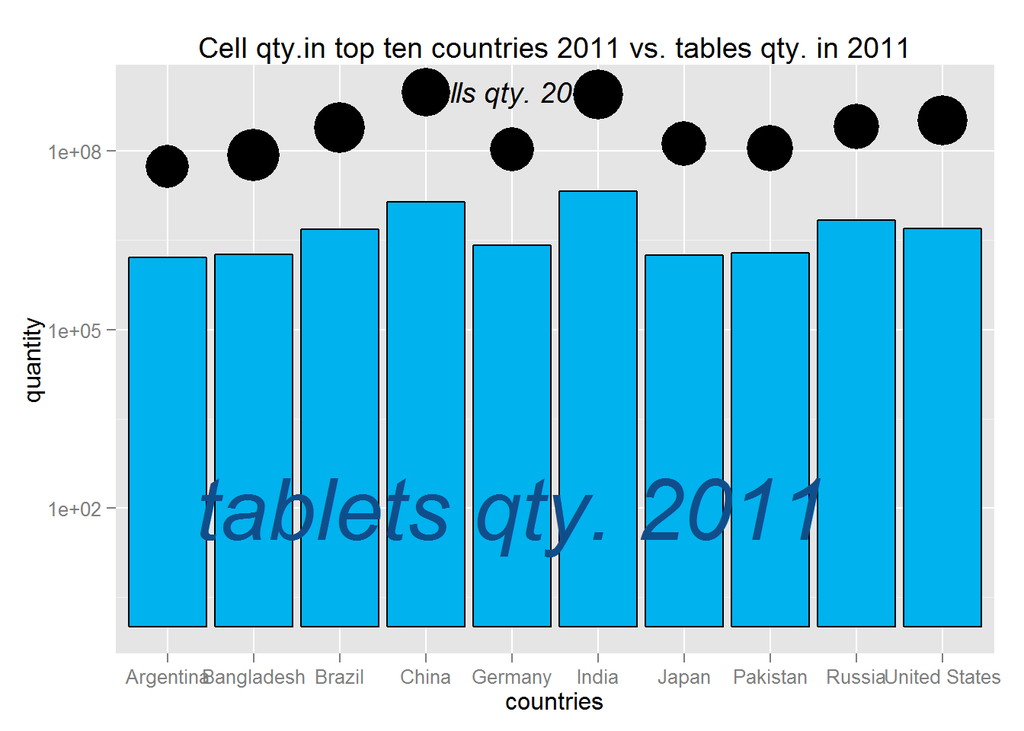

Now let’s ask, how is the relation between population, cell quantity in 2011 considering top 10 countries in the world in respect to cell qty. in 2011.

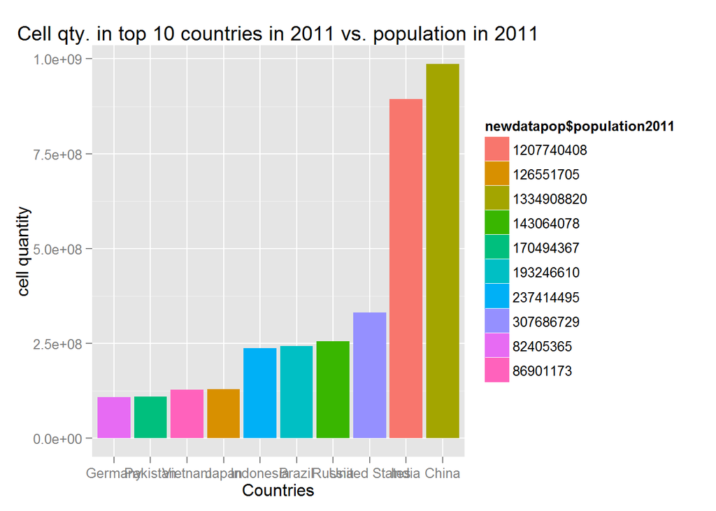

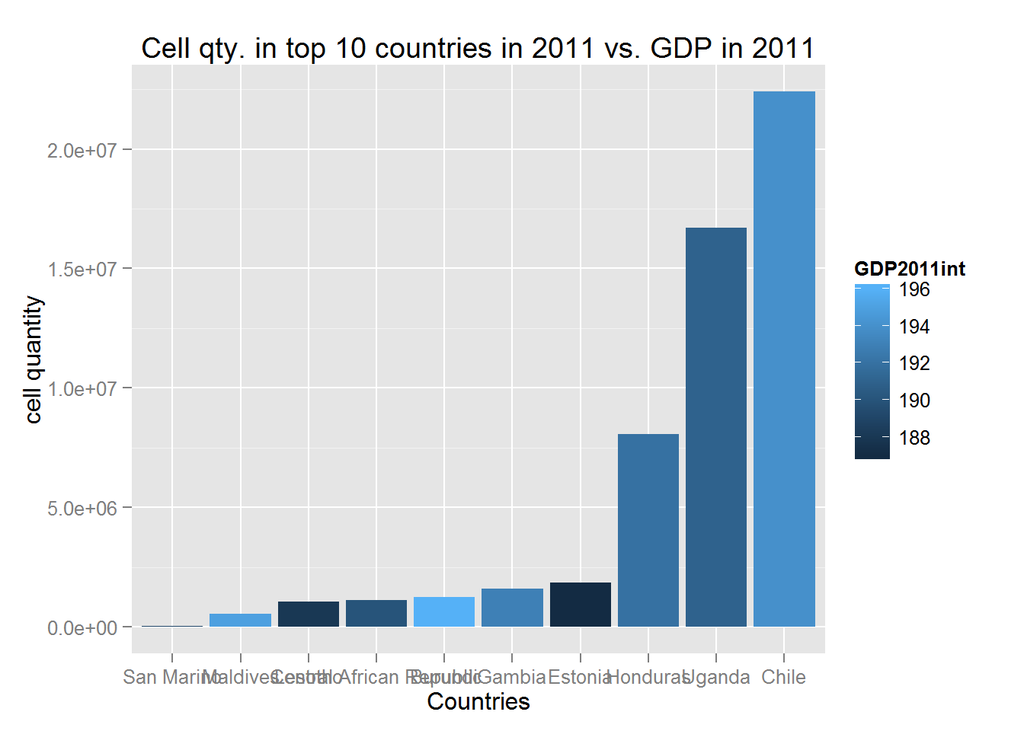

# Final Plots and Summary

### Plot One

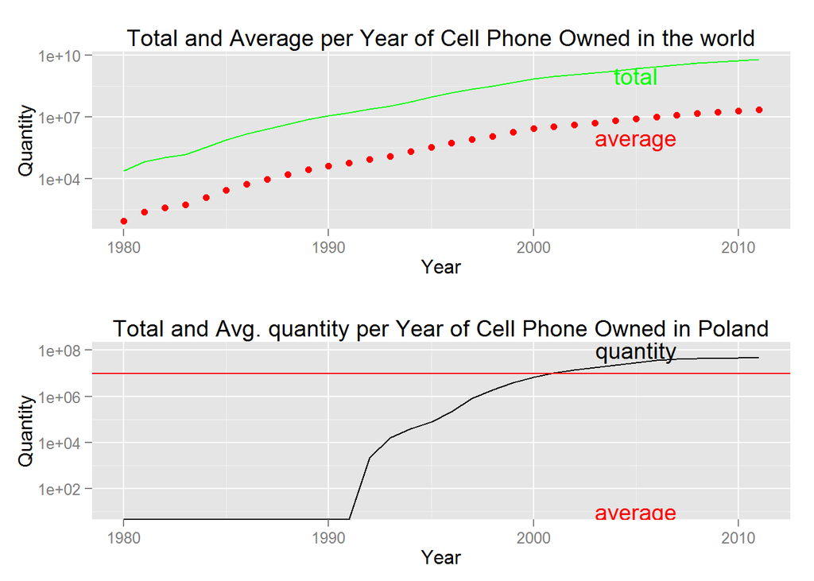

### Description One

First plot’s task is to show relation of Average and Total amount of cell phones in the world related to Poland : average and total quantityin the world. What was the most importand finding on the top plot is that in fact the year 1980 was the first one when first cell phones appeared as a technology. Since then we can see the steady growth (but we must remebmer this is logarithmic scale). On the other hand we depicted the same values for Poland, since our question was, if the growth of cells in Poland looks the same or different. We have also confirmed that western technology was not available in Poland because of communism and that the revolution of mobile phones began actually 10 years after.

### Plot Two

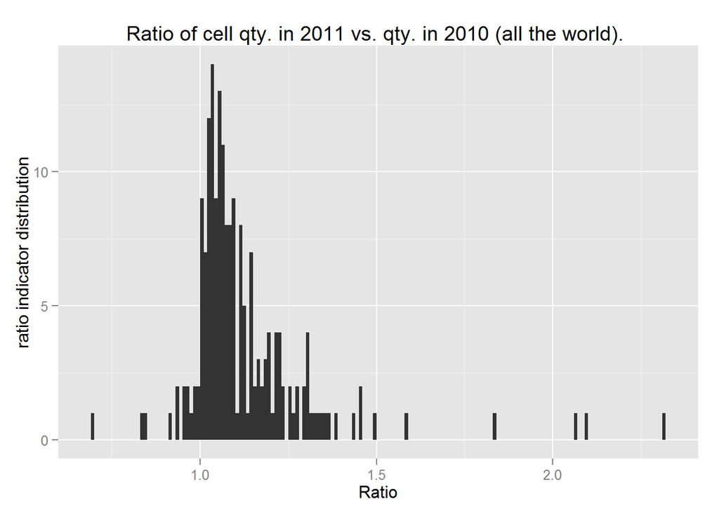

### Plot Three

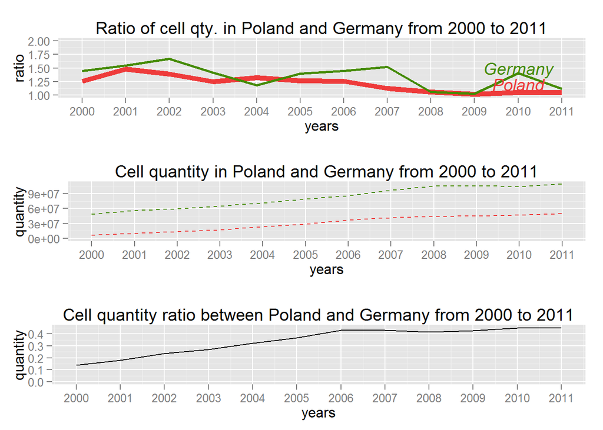

### Description Three

The final plot (3 sections) we will explore relation between two countries by taking into consideration three indicators: “ratio” indicator, that can show us what was the country/world reaction to the cell phones market over time, quantity and quantity ratio. The example analyses Poland and it’s neighbour Germany.

We can see mamy interesting events like:

-ratio in Poland was generally below Germanm so the growth German market was faster, but in 2004 Poland experienced better growth

-both countries experience bessa between 2007 and 2008

-there are three big ratio spikes fir germany, that can indicate some market trends, worth to investigate,

-finally all tends to go to 1, since the market seems to be full for cells,

# Reflection

By anlysing the data we can see the very beginning of cellular telephony in 80’ growing steadily with a boom in late 90’ and in the next decade. Poland was 10 years behind world’s trend until 1989 . Today Poland is actually the leader of LTE technology in Europe by having the most users and signal coverage with this technology and all of this came from relatively fast saturation of market and push for new technology. http://point-topic.com/free-analysis/mapping-broadband-coverage-in-poland/

First difficulty I had was related to the data itself. I had to create csv file with header and import it properly to R. If integer value was to big, R studio changed data type to character, which poses a problem. This had to be reconverted to double type. Structure shows that this is actually a spreadsheet of values. The relation before the data seems to be none or limited. In order to begin finding patterns the data had to be groupped together, visualized as a combination of features, not features alone. Since the dataset has actually rather simple structure, some of the characteristics has to be obtained by combining the data together. Finally to create more interesting analysis some of the data had to be added.

The last plot can be a great starting point for more thorough analyse. This type of plot was chosen because it is easy to read and can show not only main dependency between ratios but also a spread of values in relation one to another. It is also not obvious to interpret since growing values do not necessary mean increase/decrease of cell phones in the world or chosen country. This can help to identify some trends. Generally speaking the markets start to become saturated and that producers must change strategy to sell more by offering new services available only to modern smartphones or better prices to users, so they are willing to change old phone even if they do not need because it is still working, or maybe focus on diffenert devices like phablets and/or mobile tablet-laptop-phone.

# Resources

R CookBook

http://www.cookbook-r.com

http://www3.nd.edu/~steve/computing_with_data/11_geom_examples/ggplot_examples.html

http://www.ademcan.net

http://www.cookbook-r.com/Graphs/Axes_%28ggplot2%29/

http://www.r-bloggers.com/ggplot2-tutorial/

http://ggplot2.org/book/qplot.pdf

http://docs.ggplot2.org/0.9.3/annotate.html